# Data Tidying with tidyr

This is a reading note from Data Science with R. For more details this chapter please see http://garrettgman.github.io/tidying/.

## Prerequisites

DSR is the dataset.

```r
#install.packages(c("tidyr","devtools"))
#devtools::install_github("garrettgman/DSR")
```

## Four types of data table

```r
library(DSR)
table1
```

```
##       country year  cases population
## 1 Afghanistan 1999    745   19987071
## 2 Afghanistan 2000   2666   20595360
## 3      Brazil 1999  37737  172006362
## 4      Brazil 2000  80488  174504898
## 5       China 1999 212258 1272915272
## 6       China 2000 213766 1280428583
```

```r
table2
```

```
##        country year        key      value
## 1  Afghanistan 1999      cases        745
## 2  Afghanistan 1999 population   19987071
## 3  Afghanistan 2000      cases       2666
## 4  Afghanistan 2000 population   20595360
## 5       Brazil 1999      cases      37737
## 6       Brazil 1999 population  172006362
## 7       Brazil 2000      cases      80488
## 8       Brazil 2000 population  174504898
## 9        China 1999      cases     212258
## 10       China 1999 population 1272915272
## 11       China 2000      cases     213766
## 12       China 2000 population 1280428583
```

```r
table3
```

```
##       country year              rate
## 1 Afghanistan 1999      745/19987071
## 2 Afghanistan 2000     2666/20595360
## 3      Brazil 1999   37737/172006362
## 4      Brazil 2000   80488/174504898
## 5       China 1999 212258/1272915272
## 6       China 2000 213766/1280428583
```

```r
table4
```

```
##       country   1999   2000
## 1 Afghanistan    745   2666
## 2      Brazil  37737  80488
## 3       China 212258 213766
```

```r
table5
```

```
##       country       1999       2000
## 1 Afghanistan   19987071   20595360
## 2      Brazil  172006362  174504898
## 3       China 1272915272 1280428583
```

# So, which dataset we will consider as a tidy dataset?

## Three rules of tidy datasets

Your data will be easier to work with R if it follows three rules:

1. Each **variable** in the dataset is placed in its own **column**
2. Each **observation** is placed in its own **row**
3. Each **value** is placed in its own **cell**

Data that satisfies these rules is known as tidy data. Notice that *table1* is tidy data.

# Why we need tidy data?

## Tidy data with R

Tidy data works well with R because R is a **vectorized** programming language.

1. Data structures in R are built from **vector**
2. R’s operations are optimized to work with vectors.

Tidy data take advantage of both of these traits.

In R, a data frame is a list of vector that R displays as a table. When your data is tidy, the values of each vairable fall in their own column vector.

With tidy data, you can easily extract and manipulate the values of a variable:

```r
table1$cases
```

```
## [1]    745   2666  37737  80488 212258 213766
```

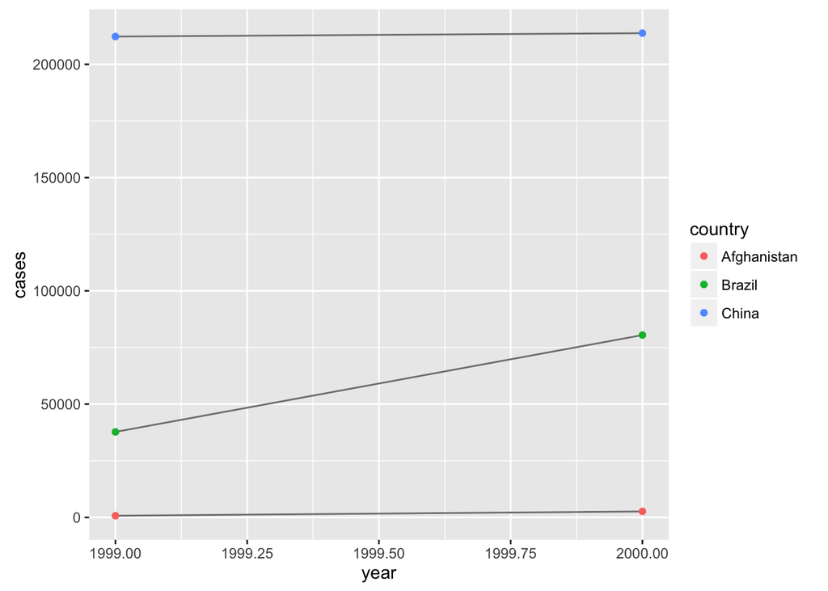

```r
# Visualise changes over time
library(ggplot2)
ggplot(table1, aes(year, cases)) +
  geom_line(aes(group = country), colour = "grey50") +
  geom_point(aes(colour = country))
```

Then you can extract abd manipulate the value of variables in tidy data with concise, simple code:

```r
mean(table1$cases)
```

```
## [1] 91276.67
```

```r
table1$cases / table1$population * 10000
```

```
## [1] 0.372741 1.294466 2.193930 4.612363 1.667495 1.669488
```

Assume that in these data sets, cases refers to the number of people diagnosed with TB per country per year. To calculate the rate of TB cases per country per year (i.e, the number of people per 10,000 diagnosed with TB), you will need to do four operations with the data. You will need to:

1. Extract the number of TB cases per country per year
2. Extract the population per country per year (in the same order as above)
3. Divide cases by population
4. Multiply by 10000

### Data set one

Since table1 is organized in a tidy fashion, you can calculate the rate like this:

```r
table1$cases / table1$population * 10000
```

```
## [1] 0.372741 1.294466 2.193930 4.612363 1.667495 1.669488
```

### Data set two

Data set two intermingles the values of population and cases in the same columns. As a result, you will need to untangle the values whenever you want to work with each variable separately.

```r
# Data set two
case_rows <- seq(1,12,2)
pop_rows <- seq(2,12,2)
table2$value[case_rows] / table2$value[pop_rows] * 10000
```

```
## [1] 0.372741 1.294466 2.193930 4.612363 1.667495 1.669488
```

### Data set three

Data set three combines the values of cases and population into the same cells. It may seem that this would help you calculate the rate, but that is not so. You will need to separate the population values from the cases values if you wish to do math with them. This can be done, **but not with “basic” R syntax**.

#### Personal Note: I’m not agree with “but not with “basic” R syntax”. So I used basic R to calculation with table 3.

```r
table3_new<-cbind(table3[,-3],t(sapply(table3[,3],function(x) unlist(strsplit(x,split='/')))))
table3_new[,3:4]<-sapply(table3_new[,3:4],function(x) as.numeric(as.character(x)))
# Note:the number need to be convert to character then numeric
rownames(table3_new)<-NULL
colnames(table3_new)[3:4]<-c("case","population")

table3_new$case/ table3_new$population* 10000
```

```
## [1] 0.372741 1.294466 2.193930 4.612363 1.667495 1.669488
```

### Data set four and five

```r
cases <- c(table4[,2], table4[,3])
population <- c(table5$'1999', table5$'2000')
cases / population * 10000
```

```
## [1] 0.372741 2.193930 1.667495 1.294466 4.612363 1.669488
```

Data set one is much easier to work with than with data sets two, three, or four. To work with data sets two, three, and four, you need to take extra steps, which makes your code harder to write, harder to understand, and harder to debug.

# spread() and gather()– reshape the layout

The tidyr package will help to tidy your data. It contains four funcions.

The two most important functions in tidyr are gather() and spread(). Each relies on the idea of a key value pair.

## Key value pairs

It’s same concept as the dictionary in python. A key value pair us a simple way to record information. Key can be regard as variable names, while value are the values of the variables.

In tidy data, each cell will contain a value and each column name will contain a key.

So when the data contains one column of variable names and another columns of corresponding values, we should use spread() and gather().

```r
table2
```

```
##        country year        key      value
## 1  Afghanistan 1999      cases        745
## 2  Afghanistan 1999 population   19987071
## 3  Afghanistan 2000      cases       2666
## 4  Afghanistan 2000 population   20595360
## 5       Brazil 1999      cases      37737
## 6       Brazil 1999 population  172006362
## 7       Brazil 2000      cases      80488
## 8       Brazil 2000 population  174504898
## 9        China 1999      cases     212258
## 10       China 1999 population 1272915272
## 11       China 2000      cases     213766
## 12       China 2000 population 1280428583
```

n table2, the key column contains only keys (and not just because the column is labelled key). Conveniently, the value column contains the values associated with those keys.

You can use the **spread()** function to tidy this layout.

## spread()- Spread rows into columns

spread() turns a pair of key:value columns into a set of tidy columns. To use spread(), pass it the name of a data frame, then the name of the key column in the data frame, and then the name of the value column. Pass the column names as they are; **do not use quotes**.

```r
library(tidyr)
spread(table2,type,count)
```

[output not shown]

spread() returns a copy of your data set that has had the key and value columns removed.

In their place, spread() adds a new column for each unique value of the key column. These unique values will form the column names of the new columns.

spread() distributes the cells of the former value column across the cells of the new columns and truncates any non-key, non-value columns in a way that prevents duplication.

In the other words, spread() will create columns to contains values, while the column names are corresponding keys.

spread() distributes a pair of key:**value** columns into a field of **cells**. The unique values of the **key** column become the **column names** of the field of cells.

### Other Arguments

1. spread() takes three optional arguments in addition to data, key, and value:
2. fill - If the tidy structure creates combinations of variables that do not exist in the original data set, spread() will place an NA in the resulting cells. NA is R’s missing value symbol. You can change this behaviour by passing fill an alternative value to use.
3. convert - If a value column contains **multiple types** of data, its elements will be saved as a single type, usually character strings. As a result, the new columns created by spread() will also contain character strings. If you set convert = TRUE, spread() will run type.convert() on each new column, which will **convert strings to doubles (numerics), integers, logicals, complexes, or factors**.
4. drop - The drop argument controls how spread() handles factors in the key column. If you set drop = FALSE, spread will **keep factor levels** that do not appear in the key column, filling in the missing combinations with the value of fill.

## gather()- Gather columns into rows.

gather() does the **reverse** of spread(). gather() collects a set of column names and places them into a single “key” column. It also collects the cells of those columns and places them into a single value column. You can use gather() to tidy table4.

```r
table4a
```

```
## # A tibble: 3 x 3
##       country   1999   2000
## *       <chr>  <int>  <int>
## 1 Afghanistan    745   2666
## 2      Brazil  37737  80488
## 3       China 212258 213766
```

To use gather(), pass it the name of a data frame to reshape. Then pass gather() **a character string** to use for the name of the “key” column that it will make, as well as a character string to use as the name of the value column that it will make. Finally, specify which columns gather() should collapse into the key value pair (here with integer notation).

```r
gather(table4a,"year","case",2:3)
```

```
## # A tibble: 6 x 3
##       country  year   case
##         <chr> <chr>  <int>
## 1 Afghanistan  1999    745
## 2      Brazil  1999  37737
## 3       China  1999 212258
## 4 Afghanistan  2000   2666
## 5      Brazil  2000  80488
## 6       China  2000 213766
```

```r
# year for the variable names
# case for the variable values

# Another way to gather
table4a %>%
  gather(key = "year", value = "cases",`1999`, `2000`)
```

```
## # A tibble: 6 x 3
##       country  year  cases
##         <chr> <chr>  <int>
## 1 Afghanistan  1999    745
## 2      Brazil  1999  37737
## 3       China  1999 212258
## 4 Afghanistan  2000   2666
## 5      Brazil  2000  80488
## 6       China  2000 213766
```

gather() returns a copy of the data frame with the specified columns removed. To this data frame, gather() has added two new columns: a “key” column that contains the former column names of the removed columns, and a value column that contains the former values of the removed columns.

gather() repeats each of the former column names (as well as each of the original columns) to maintain each combination of values that appeared in the original data set. gather() uses the first string that you supplied as the name of the new “key” column, and it uses the second string as the name of the new value column.

We can do the same to table 4b:

```r
table4b
```

```
## # A tibble: 3 x 3
##       country       1999       2000
## *       <chr>      <int>      <int>
## 1 Afghanistan   19987071   20595360
## 2      Brazil  172006362  174504898
## 3       China 1272915272 1280428583
```

```r
gather(table4b,"year","population",2:3)
```

```
## # A tibble: 6 x 3
##       country  year population
##         <chr> <chr>      <int>
## 1 Afghanistan  1999   19987071
## 2      Brazil  1999  172006362
## 3       China  1999 1272915272
## 4 Afghanistan  2000   20595360
## 5      Brazil  2000  174504898
## 6       China  2000 1280428583
```

```r
## Another way
gather(table4b,"year","population",-1)
```

```
## # A tibble: 6 x 3
##       country  year population
##         <chr> <chr>      <int>
## 1 Afghanistan  1999   19987071
## 2      Brazil  1999  172006362
## 3       China  1999 1272915272
## 4 Afghanistan  2000   20595360
## 5      Brazil  2000  174504898
## 6       China  2000 1280428583
```

```r
## Another way using pipe
table4b %>%
  gather(key = "year", value = "population",`1999`, `2000`)
```

```
## # A tibble: 6 x 3
##       country  year population
##         <chr> <chr>      <int>
## 1 Afghanistan  1999   19987071
## 2      Brazil  1999  172006362
## 3       China  1999 1272915272
## 4 Afghanistan  2000   20595360
## 5      Brazil  2000  174504898
## 6       China  2000 1280428583
```

You can also identify columns by name with the notation introduced by the **select()** in dplyr

### Combine table4a and table4b together using dplyr

```r
library(dplyr)
tidy4a <- table4a %>%
  gather(`1999`, `2000`, key = "year", value = "cases")
tidy4b <- table4b %>%
  gather(`1999`, `2000`, key = "year", value = "population")
left_join(tidy4a, tidy4b,by=c("country", "year"))
```

```
## # A tibble: 6 x 4
##       country  year  cases population
##         <chr> <chr>  <int>      <int>
## 1 Afghanistan  1999    745   19987071
## 2      Brazil  1999  37737  172006362
## 3       China  1999 212258 1272915272
## 4 Afghanistan  2000   2666   20595360
## 5      Brazil  2000  80488  174504898
## 6       China  2000 213766 1280428583
```

## Exercises

### 1. Why are gather() and spread() not perfectly symmetrical?

Carefully consider the following example:

```r
stocks <- data_frame(
  year   = c(2015, 2015, 2016, 2016),
  half  = c(   1,    2,     1,    2),
  return = c(1.88, 0.59, 0.92, 0.17)
)
stocks %>%
  spread(year, return) %>%
  gather("year", "return", `2015`:`2016`)
```

```
## # A tibble: 4 x 3
##    half  year return
##   <dbl> <chr>  <dbl>
## 1     1  2015   1.88
## 2     2  2015   0.59
## 3     1  2016   0.92
## 4     2  2016   0.17
```

1. The orders of column names would change
2. The types of year change from double to character.

Both spread() and gather() have a convert argument. Let’s try to use this to fix the 2nd problem

```r
stocks %>%
  spread(year, return, convert=T) %>%
  gather("year", "return", `2015`:`2016`,convert=T)
```

```
## # A tibble: 4 x 3
##    half  year return
##   <dbl> <int>  <dbl>
## 1     1  2015   1.88
## 2     2  2015   0.59
## 3     1  2016   0.92
## 4     2  2016   0.17
```

Using convert=T in gather() only change the type of year to int, didn’t maintain the original type

### 2. Why does this code fail?

```r
#table4a %>%
#  gather(1999, 2000, key = "year", value = "cases")
```

```
#> Error in eval(expr, envir, enclos): Error: Position must be between 0 and n
```

If we use 1999, 2000 without “”, it will indicate **the indices of columns** so it try to find 1999th and 2000th columns . So, you need “” to indicate these is the names.

### 3. Why does spreading this tibble fail? How could you add a new column to fix the problem?

```r
people <- frame_data(
  ~name, ~key, ~value,
  "Phillip Woods","age",       45,
  "Phillip Woods",   "height",   186,
  "Phillip Woods",   "age",       50,
  "Jessica Cordero", "age",       37,
  "Jessica Cordero", "height",   156
)
# frame_data helps you to do Row-Wise Data_frame Creation
people
```

```
## # A tibble: 5 x 3
##              name    key value
##             <chr>  <chr> <dbl>
## 1   Phillip Woods    age    45
## 2   Phillip Woods height   186
## 3   Phillip Woods    age    50
## 4 Jessica Cordero    age    37
## 5 Jessica Cordero height   156
```

```r
# if you get error on this one, you need to re-install the dplyr package
# try to spread()
# people %>%
#   spread(key,value)
#Error: Duplicate identifiers for rows (1, 3)

## the people have 2 age records, we can give an index column

## the first way
people1=people
people1$row <- 1:nrow(people1)
wide <- spread(people1, key,value)

## the second way
people %>%
   group_by(name, key) %>%
   summarise(value=toString(unique(value))) %>%
   spread(key,value, fill='')
```

```
## Source: local data frame [2 x 3]
## Groups: name [2]
##
##              name    age height
## *           <chr>  <chr>  <chr>
## 1 Jessica Cordero     37    156
## 2   Phillip Woods 45, 50    186
```

The solution is from thess link

1. http://stackoverflow.com/questions/25960394/unexpected-behavior-with-tidyr
2. http://stackoverflow.com/questions/31209388/r-spread-function-on-data-frame-with-duplicates

### 3. Tidy the simple tibble below. Do you need to spread or gather it? What are the variables?

```r
preg <- frame_data(
  ~pregnant, ~male, ~female,
  "yes",     NA,    10,
  "no",      20,    12
)

# I will ctrat a variable called gender
gather(preg,"gender","count",-1)
```

```
## # A tibble: 4 x 3
##   pregnant gender count
##      <chr>  <chr> <dbl>
## 1      yes   male    NA
## 2       no   male    20
## 3      yes female    10
## 4       no female    12
```

# separate() and unite()–split and combine cells

spread() and gather() help you reshape the layout of your data to place variables in columns and observations in rows. separate() and unite() help you split and combine cells to place a single, complete value in each cell.

## separate()- Separate one column into several

To use separate() pass separate the name of a data frame to reshape and the name of a column to separate. Also give separate() an into argument, which should be a vector of character strings to use as new column names.

separate() will return a copy of the data frame with the column removed. The previous values of the column will be split across several columns, one for each name in into.

```r
table3
```

```
## # A tibble: 6 x 3
##       country  year              rate
## *       <chr> <int>             <chr>
## 1 Afghanistan  1999      745/19987071
## 2 Afghanistan  2000     2666/20595360
## 3      Brazil  1999   37737/172006362
## 4      Brazil  2000   80488/174504898
## 5       China  1999 212258/1272915272
## 6       China  2000 213766/1280428583
```

```r
separate(table3, rate, into = c("cases","population") )
```

```
## # A tibble: 6 x 4
##       country  year  cases population
## *       <chr> <int>  <chr>      <chr>
## 1 Afghanistan  1999    745   19987071
## 2 Afghanistan  2000   2666   20595360
## 3      Brazil  1999  37737  172006362
## 4      Brazil  2000  80488  174504898
## 5       China  1999 212258 1272915272
## 6       China  2000 213766 1280428583
```

```r
## Another way using pipe
table3 %>%
  separate(rate, into = c("cases", "population"))
```

```
## # A tibble: 6 x 4
##       country  year  cases population
## *       <chr> <int>  <chr>      <chr>
## 1 Afghanistan  1999    745   19987071
## 2 Afghanistan  2000   2666   20595360
## 3      Brazil  1999  37737  172006362
## 4      Brazil  2000  80488  174504898
## 5       China  1999 212258 1272915272
## 6       China  2000 213766 1280428583
```

By default, separate() will split values wherever a **non-alphanumeric character** appears. Non-alphanumeric characters are characters that are neither a number nor a letter. For example, in the code above, separate() split the values of rate at the forward slash characters.

### Other argument – sep

#### Specify symbols using sep = “symbol”

If you wish to use a specific character to separate a column, you can pass the character to the sep argument of separate(). For example, we could rewrite the code above as

```r
separate(table3,rate,into=c("case","population"),sep="/")
```

```
## # A tibble: 6 x 4
##       country  year   case population
## *       <chr> <int>  <chr>      <chr>
## 1 Afghanistan  1999    745   19987071
## 2 Afghanistan  2000   2666   20595360
## 3      Brazil  1999  37737  172006362
## 4      Brazil  2000  80488  174504898
## 5       China  1999 212258 1272915272
## 6       China  2000 213766 1280428583
```

```r
## Another solution using pipe
table3 %>%
  separate(rate, into = c("cases", "population"), sep = "/")
```

```
## # A tibble: 6 x 4
##       country  year  cases population
## *       <chr> <int>  <chr>      <chr>
## 1 Afghanistan  1999    745   19987071
## 2 Afghanistan  2000   2666   20595360
## 3      Brazil  1999  37737  172006362
## 4      Brazil  2000  80488  174504898
## 5       China  1999 212258 1272915272
## 6       China  2000 213766 1280428583
```

#### Specify digits using sep = num

You can also pass an integer or vector of integers to sep. separate() will interpret the integers as positions to split at. **Positive** values start at 1 at the **far-left** of the strings; **negative** value start at -1 at the **far-right** of the strings. The length of sep should be one less than the number of names in into. You can use this arrangement to separate the last two digits of each year.

```r
table3 %>%
  separate(year, into = c("century", "year"), sep = 2)
```

```
## # A tibble: 6 x 4
##       country century  year              rate
## *       <chr>   <chr> <chr>             <chr>
## 1 Afghanistan      19    99      745/19987071
## 2 Afghanistan      20    00     2666/20595360
## 3      Brazil      19    99   37737/172006362
## 4      Brazil      20    00   80488/174504898
## 5       China      19    99 212258/1272915272
## 6       China      20    00 213766/1280428583
```

You can futher customize separate() with the remove, convert, and extra arguments:

1. remove - Set **remove = FALSE** to **retain** the column of values that were separated in the final data frame.
2. convert - By default, separate() will return new columns as character columns. Set **convert = TRUE** to convert new columns to double (numeric), integer, logical, complex, and factor columns with type.convert().
3. extra - extra controls what happens when the number of new values in a cell does not match the number of new columns in into. If **extra = error (the default)**, separate() to return an error. If **extra = drop**, separate() will **drop new values** and **supply NAs** as necessary to fill the new columns. If extra = merge, separate() will split at most length(into) times.

Look carefully at the column types: you’ll notice that case and population are character columns. This is the default behaviour in separate(): it leaves the type of the column as is. Here, however, it’s not very useful those really are numbers. We can ask separate() to try and convert to better types using convert = TRUE:

```r
table3 %>%
  separate(rate, into = c("cases", "population"), convert = TRUE)
```

```
## # A tibble: 6 x 4
##       country  year  cases population
## *       <chr> <int>  <int>      <int>
## 1 Afghanistan  1999    745   19987071
## 2 Afghanistan  2000   2666   20595360
## 3      Brazil  1999  37737  172006362
## 4      Brazil  2000  80488  174504898
## 5       China  1999 212258 1272915272
## 6       China  2000 213766 1280428583
```

## unite()- Unite several columns into one

unite() does the opposite of separate(): it combines multiple columns into a single column.

We can use unite() to rejoin the century and year columns that we created in the last example. That data is saved in the DSR package as table6.

Give unite() the name of the data frame to reshape, the name of the new column to create (as a **character** string), and the names of the columns to unite. unite() will place an **underscore (_)** between values from separate columns. If you would like to use a different separator, or no separator at all, pass the separator as a character string to sep.

```r
unite(table6,"new",century,year,sep="")
```

```
## # A tibble: 6 x 3
##       country   new              rate
## *      <fctr> <chr>             <chr>
## 1 Afghanistan  1999      745/19987071
## 2 Afghanistan  2000     2666/20595360
## 3      Brazil  1999   37737/172006362
## 4      Brazil  2000   80488/174504898
## 5       China  1999 212258/1272915272
## 6       China  2000 213766/1280428583
```

```r
# if no sep="", then connect with _
unite(table6,"new",century,year)
```

```
## # A tibble: 6 x 3
##       country   new              rate
## *      <fctr> <chr>             <chr>
## 1 Afghanistan 19_99      745/19987071
## 2 Afghanistan 20_00     2666/20595360
## 3      Brazil 19_99   37737/172006362
## 4      Brazil 20_00   80488/174504898
## 5       China 19_99 212258/1272915272
## 6       China 20_00 213766/1280428583
```

unite() returns a copy of the data frame that includes the new column, but **not the columns used to build the new column**. If you would like to retain these columns, add the argument remove = FALSE

# Case study

To see the data in its raw form, load DSR with library(DSR) then run

```r
#View(who)
dim(who)
```

```
## [1] 7240   60
```

who provides a realistic example of tabular data in the wild. It contains redundant columns, odd variable codes, and many missing values. In short, who is messy.

The most unique feature of who is its coding system. Columns five through sixty encode four separate pieces of information in their column names:

The first three letters of each column denote whether the column contains new or old cases of TB. In this data set, each column contains new cases.

The next two letters describe the type of case being counted. We will treat each of these as a separate variable.

- rel stands for cases of relapse
- ep stands for cases of extrapulmonary TB
- sn stands for cases of pulmonary TB that could not be diagnosed by a pulmonary smear (smear negative)
- sp stands for cases of pulmonary TB that could be diagnosed be a pulmonary smear (smear positive)
- The sixth letter describes the sex of TB patients. The data set groups cases by males (m) and females (f).

The remaining numbers describe the age group of TB patients. The data set groups cases into seven age groups:

- 014 stands for patients that are 0 to 14 years old
- 1524 stands for patients that are 15 to 24 years old
- 2534 stands for patients that are 25 to 34 years old
- 3544 stands for patients that are 35 to 44 years old
- 4554 stands for patients that are 45 to 54 years old
- 5564 stands for patients that are 55 to 64 years old
- 65 stands for patients that are 65 years old or older

### Step1:

Notice that the who data set is untidy in multiple ways. First, the data appears to contain values in its column names. We can move the values into their own column with gather(). This will make it easy to separate the values combined in each code.

```r
who<-gather(who,"code","value",5:60)
head(who)
```

```
## # A tibble: 6 x 6
##       country  iso2  iso3  year        code value
##         <chr> <chr> <chr> <int>       <chr> <int>
## 1 Afghanistan    AF   AFG  1980 new_sp_m014    NA
## 2 Afghanistan    AF   AFG  1981 new_sp_m014    NA
## 3 Afghanistan    AF   AFG  1982 new_sp_m014    NA
## 4 Afghanistan    AF   AFG  1983 new_sp_m014    NA
## 5 Afghanistan    AF   AFG  1984 new_sp_m014    NA
## 6 Afghanistan    AF   AFG  1985 new_sp_m014    NA
```

Next, we want to separate the column into age and gender information. We can separate the values in each code with two passes of separate(). The first pass will split the codes at each underscore.

Note: Some of the code are “newrel_m5564 (int)”, “newrel_m65”

```r
who<-separate(who,code,into=c("new", "sexage"),sep=7)
who<-separate(who,new,into=c("new", "var"))
who[1:5,]
```

```
## # A tibble: 5 x 8
##       country  iso2  iso3  year   new   var sexage value
##         <chr> <chr> <chr> <int> <chr> <chr>  <chr> <int>
## 1 Afghanistan    AF   AFG  1980   new    sp   m014    NA
## 2 Afghanistan    AF   AFG  1981   new    sp   m014    NA
## 3 Afghanistan    AF   AFG  1982   new    sp   m014    NA
## 4 Afghanistan    AF   AFG  1983   new    sp   m014    NA
## 5 Afghanistan    AF   AFG  1984   new    sp   m014    NA
```

The second pass will split sexage after the first character to create a sex column and an age column.

```r
who <- separate(who, sexage, c("sex", "age"), sep = 1)
who[c(1,45,1024,1314,405200,405440),]
```

```
## # A tibble: 6 x 9
##                    country  iso2  iso3  year    new   var   sex   age
##                      <chr> <chr> <chr> <int>  <chr> <chr> <chr> <chr>
## 1              Afghanistan    AF   AFG  1980    new    sp     m   014
## 2                  Albania    AL   ALB  1990    new    sp     m   014
## 3        Brunei Darussalam    BN   BRN  2013    new    sp     m   014
## 4 Central African Republic    CF   CAF  1997    new    sp     m   014
## 5                  Vanuatu    VU   VUT  2011 newrel           f    65
## 6                 Zimbabwe    ZW   ZWE  2013 newrel           f    65
## # ... with 1 more variables: value <int>
```

```r
who <- spread(who, var, value,drop = T)[,-8] # drop the empty one
who[1:5,]
```

```
## # A tibble: 5 x 10
##       country  iso2  iso3  year   new   sex   age    ep    sn    sp
##         <chr> <chr> <chr> <int> <chr> <chr> <chr> <int> <int> <int>
## 1 Afghanistan    AF   AFG  1980   new     m   014    NA    NA    NA
## 2 Afghanistan    AF   AFG  1981   new     m   014    NA    NA    NA
## 3 Afghanistan    AF   AFG  1982   new     m   014    NA    NA    NA
## 4 Afghanistan    AF   AFG  1983   new     m   014    NA    NA    NA
## 5 Afghanistan    AF   AFG  1984   new     m   014    NA    NA    NA
```